# 32-beta_diversity

Author

Jinling Xue

Updated: 2023-03-04 23:53:11 CET.

```r
library(here)
library(tidyverse)
library(vegan)
library(ape)
```

## Tasks

### PCOA_TIME_TRY1.R

code from: `~/project/p0064gvhd/workflow/data/00-raw/result/Beta_Diversity/PCOA/PCOA_TIME_TRY1.R`

```
species scores not available
```

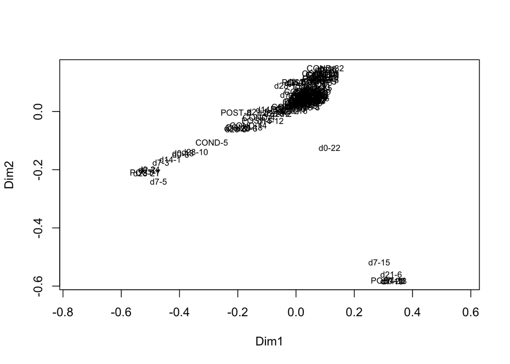

```r
fin11 <- here(path_data, 'virome-RA-Time.txt')
fin12 <- here(path_data, 'grouping-Time.txt')
fout11 <- path_target('Time-distance.csv')
fout12 <- path_target('pcoa.virome-time.csv')
fout13 <- path_target('pcoa.otu.time.csv')
fout14 <- path_target('V.Time.sample-group.csv')
fout15 <- path_target("PCOA_TIME_TRY123_NEW.png")

otu <- read.delim(fin11, row.names = 1, sep = '\t', stringsAsFactors = FALSE, check.names = FALSE) %>%
  t() %>%
  data.frame()

group <- read.delim(fin12, sep = '\t', stringsAsFactors = FALSE)
distance <- vegdist(otu, method = 'bray')
pcoa <- cmdscale(distance, k = (nrow(otu) - 1), eig = TRUE)
write.csv(as.matrix(distance), fout11, quote = F)

ordiplot(scores(pcoa)[ ,c(1, 2)], type = 't')
```

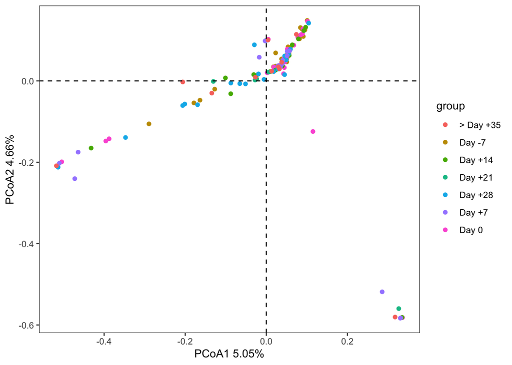

```r
point <- data.frame(pcoa$point)
write.csv(point, fout12)
species <- wascores(pcoa$points[,1:2], otu)
write.csv(species, fout13)
pcoa_eig <- (pcoa$eig)[1:2] / sum(pcoa$eig)
sample_group <- data.frame({pcoa$point})[1:2]
sample_group$names <- rownames(sample_group)
names(sample_group)[1:2] <- c('PCoA1', 'PCoA2')
sample_group <- merge(sample_group, group, by = 'names', all.x = TRUE)
write.csv(sample_group, fout14, quote = F, row.names = F)

#modify(sample_group)
pcoa <- data.table::fread(fout14)
plot.theme = theme(plot.title=element_text(size=18, color="black", family  = "Arial", face= "plain",vjust=0.5,hjust=0.5),
                   axis.line=element_line(size=.5, colour="black"),
                   axis.ticks=element_line(color="black"),
                   axis.text= element_text(size=18, color="black", family  = "Arial", face= "plain", vjust=0.5, hjust=0.5),
                   axis.title = element_text(size=18, color="black", family  = "Arial",face= "plain", vjust=0.5, hjust=0.5),
                   legend.position="right",
                   legend.background=element_blank(),
                   legend.key=element_blank(),
                   legend.text = element_text(colour = 'black', size = 18,  family  = "Arial",face = 'plain'),
                   legend.title=element_blank(),
                   panel.background=element_blank(),
                   panel.grid.major=element_blank(),
                   panel.grid.minor=element_blank()  )
pcoa_plot <- ggplot(pcoa, aes(PCoA1, PCoA2, group = group, color = group))+
  geom_point()+
  theme_bw()+
  theme(panel.grid = element_blank())+
  geom_vline(xintercept = 0,lty="dashed")+
  geom_hline(yintercept = 0,lty="dashed")+
  labs(x=paste0("PCoA1 ",5.05,"%"),
       y=paste0("PCoA2 ",4.66,"%"))

pcoa_plot
```

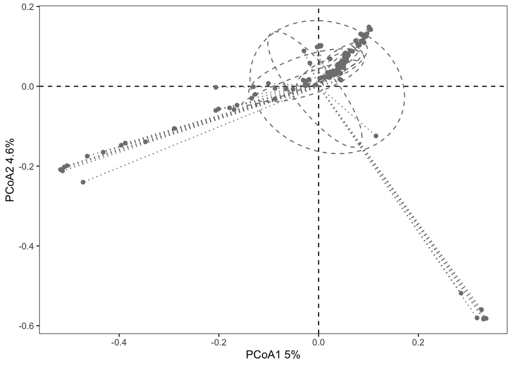

```r
P1<-ggplot(pcoa, aes(PCoA1, PCoA2, group = group, color = group))+
  geom_point(size=1)+
  theme_bw()+
  theme(panel.grid = element_blank())+
  geom_vline(xintercept = 0,lty="dashed")+
  geom_hline(yintercept = 0,lty="dashed")+
  labs(x=paste0("PCoA1 ",5.0,"%"),
       y=paste0("PCoA2 ",4.6,"%"))+
  geom_point()+scale_color_manual(values =c("d -7"="#3F7F02","d 0"="#FDCC65", "d +7"="#FC8008","d +14"="#FC6665","d +21"="#FB0106","d +28"="#FB027F"))+
  geom_segment(data=NULL,aes(x=0,y=0,xend=PCoA1,yend=PCoA2),linetype = "dotted",arrow =NULL, size = 0.5) +
  scale_fill_discrete(breaks=c("d -7","d 0","d +7","d +14","d +21","d +28"))+
  stat_ellipse(aes(colour = group),level=0.4,linetype = 2,fill=group)+theme(legend.position="none")
P1
```

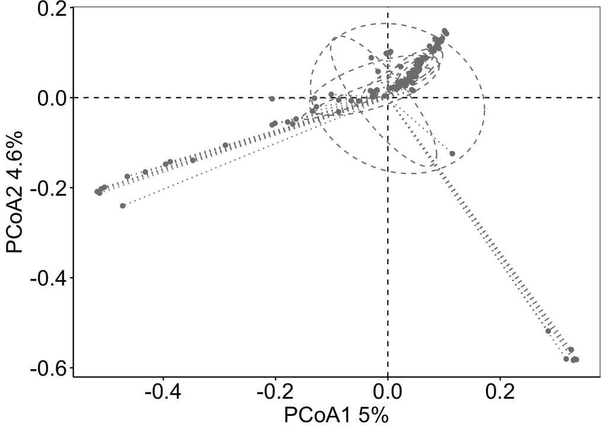

```r
plot.theme = theme(plot.title=element_text(size=18, color="black", family  = "Arial", face= "plain",vjust=0.5,hjust=0.5),
                   axis.line=element_line(size=.5, colour="black"),
                   axis.ticks=element_line(color="black"),
                   axis.text= element_text(size=18, color="black", family  = "Arial", face= "plain", vjust=0.5, hjust=0.5),
                   axis.title = element_text(size=18, color="black", family  = "Arial",face= "plain", vjust=0.5, hjust=0.5),
                   legend.position="right",
                   legend.background=element_blank(),
                   legend.key=element_blank(),
                   legend.text = element_text(colour = 'black', size = 12,  family  = "Arial",face = 'plain'),
                   legend.title=element_blank(),
                   panel.background=element_blank(),
                   panel.grid.major=element_blank(),
                   panel.grid.minor=element_blank()  )

p2 = P1 + plot.theme
p2
```

```r
ggsave(fout15, p2, width =1600,height = 1200,units = "px" )
```

### PCOA_ABX_TRY_2.R

code from: `~/project/p0064gvhd/workflow/data/00-raw/result/Beta_Diversity/PCOA/PCOA_ABX_TRY_2.R`

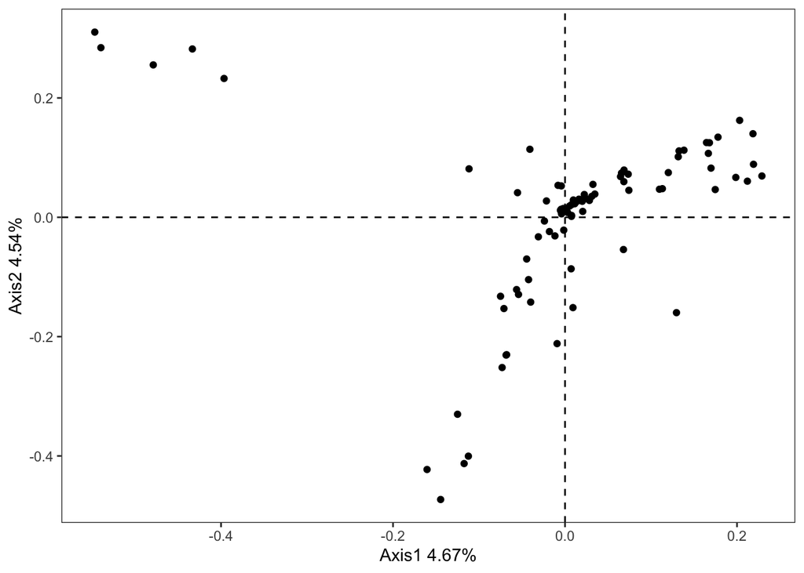

```r
fin21 <- here(path_data, 'virome_ABX_patient.txt')
fin22 <- here(path_data, 'group_ABX_patient.txt')
fout21 <- path_target('ABX_patient_distance.csv')
fout22 <- path_target("PCOA_ABX_patient_NEW.png")

otu <- read.delim(fin21, row.names = 1, sep = '\t', stringsAsFactors = FALSE, check.names = FALSE) %>%
  t() %>%
  data.frame()

group <- read.delim(fin22, sep = '\t', stringsAsFactors = FALSE)
distance <- vegdist(otu, method = 'bray')
pcoa <- cmdscale(distance, k = (nrow(otu) - 1), eig = TRUE)
write.csv(as.matrix(distance), fout21, quote = F)

df.pcoa<-pcoa(distance,correction = "cailliez")
df.plot<-data.frame(df.pcoa$vectors)

x_label<-round(df.pcoa$values$Rel_corr_eig[1]*100,2)
y_label<-round(df.pcoa$values$Rel_corr_eig[2]*100,2)

ggplot(data=df.plot,aes(x=Axis.1,y=Axis.2))+
  geom_point()+
  theme_bw()+
  theme(panel.grid = element_blank())+
  geom_vline(xintercept = 0,lty="dashed")+
  geom_hline(yintercept = 0,lty="dashed")+
  labs(x=paste0("Axis1 ",x_label,"%"),
       y=paste0("Axis2 ",y_label,"%"))
```

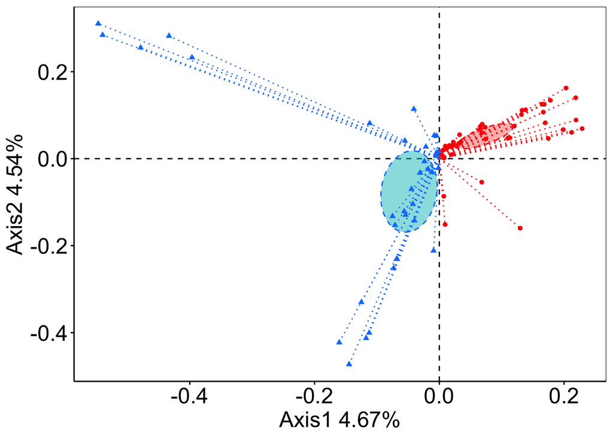

```r
df.plot$group<-ifelse(df.plot$Axis.1<0,"No ABX","ABX")

pcoa_plot<-ggplot(data=df.plot,aes(x=Axis.1,y=Axis.2,
                        color=group,shape=group))+
  geom_point(size=1)+
  theme_bw()+
  theme(panel.grid = element_blank())+
  geom_vline(xintercept = 0,lty="dashed")+
  geom_hline(yintercept = 0,lty="dashed")+
  labs(x=paste0("Axis1 ",x_label,"%"),
       y=paste0("Axis2 ",y_label,"%"))+
  stat_ellipse(aes(colour = group, fill=group),linetype = 2, level=0.2, geom = "polygon", alpha=0.5)+
  geom_point()+scale_color_manual(values =c("No ABX"="#0F7FFE","ABX"="#FB0106"))+
  geom_segment(data=NULL,aes(x=0,y=0,xend=Axis.1,yend=Axis.2),linetype = "dotted",arrow =NULL, size = 0.5) +
  scale_fill_discrete(breaks=c("No ABX","ABX"))+theme(legend.position="none")

plot.theme = theme(plot.title=element_text(size=18, color="black", family  = "Arial", face= "plain",vjust=0.5,hjust=0.5),
                   axis.line=element_line(size=.5, colour="black"),
                   axis.ticks=element_line(color="black"),
                   axis.text= element_text(size=18, color="black", family  = "Arial", face= "plain", vjust=0.5, hjust=0.5),
                   axis.title = element_text(size=18, color="black", family  = "Arial",face= "plain", vjust=0.5, hjust=0.5),
                   legend.position="none",
                   legend.background=element_blank(),
                   legend.key=element_blank(),
                   legend.text = element_text(colour = 'black', size = 18,  family  = "Arial",face = 'plain'),
                   legend.title=element_blank(),
                   panel.background=element_blank(),
                   panel.grid.major=element_blank(),
                   panel.grid.minor=element_blank()  )
p1 = pcoa_plot + plot.theme
p1
```

```r
ggsave(fout22, p1, width =1600,height = 1200,units = "px" )
```

### PCOA_CTRL_TRY1.R

code from: `~/project/p0064gvhd/workflow/data/00-raw/result/Beta_Diversity/PCOA/PCOA_CTRL_TRY1.R`

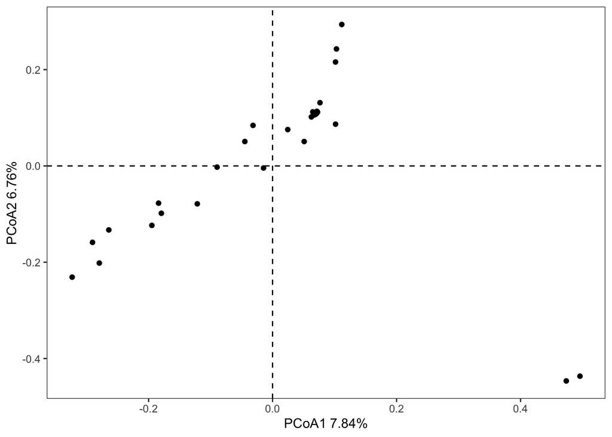

```r
fin31 <- here(path_data, 'virome_GVHD_patient.txt')
fin32 <- here(path_data, 'group_GVHD_patient.txt')
fout31 <- path_target('GVHD_patient_distance.csv')
fout32 <- path_target("PCOA_GVHD_patient_NEW.png")

otu <- read.delim(fin31, row.names = 1, sep = '\t', stringsAsFactors = FALSE, check.names = FALSE) %>%
  t() %>%
  data.frame()

group <- read.delim(fin32, sep = '\t', stringsAsFactors = FALSE)
distance <- vegdist(otu, method = 'bray')
pcoa <- cmdscale(distance, k = (nrow(otu) - 1), eig = TRUE)
write.csv(as.matrix(distance), fout31, quote = F)

df.pcoa<-pcoa(distance,correction = "cailliez")
df.plot<-data.frame(df.pcoa$vectors)
x_label<-round(df.pcoa$values$Rel_corr_eig[1]*100,2)
y_label<-round(df.pcoa$values$Rel_corr_eig[2]*100,2)
ggplot(data=df.plot,aes(x=Axis.1,y=Axis.2))+
  geom_point()+
  theme_bw()+
  theme(panel.grid = element_blank())+
  geom_vline(xintercept = 0,lty="dashed")+
  geom_hline(yintercept = 0,lty="dashed")+
  labs(x=paste0("PCoA1 ",7.84,"%"),
       y=paste0("PCoA2 ",6.76,"%"))
```

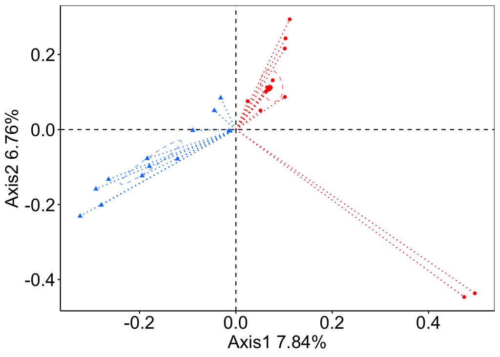

```r
df.plot$group<-ifelse(df.plot$Axis.1<0,"No GI-GvHD","GI-GvHD")

pcoa_plot<-ggplot(data=df.plot,aes(x=Axis.1,y=Axis.2,
                                   color=group,shape=group))+
  geom_point(size=1)+
  theme_bw()+
  theme(panel.grid = element_blank())+
  geom_vline(xintercept = 0,lty="dashed")+
  geom_hline(yintercept = 0,lty="dashed")+
  labs(x=paste0("Axis1 ",7.84,"%"),
       y=paste0("Axis2 ",6.76,"%"))+
  stat_ellipse(aes(colour = group, fill=group),linetype = 2, level=0.2, alpha=0.5)+
  geom_point()+scale_color_manual(values =c("No GI-GvHD"="#0F7FFE","GI-GvHD"="#FB0106"))+
  geom_segment(data=NULL,aes(x=0,y=0,xend=Axis.1,yend=Axis.2),linetype = "dotted",arrow =NULL, size = 0.5) +
  scale_fill_discrete(breaks=c("No GI-GvHD","GI-GvHD"))+theme(legend.position="none")
plot.theme = theme(plot.title=element_text(size=18, color="black", family  = "Arial", face= "plain",vjust=0.5,hjust=0.5),
                   axis.line=element_line(size=.5, colour="black"),
                   axis.ticks=element_line(color="black"),
                   axis.text= element_text(size=18, color="black", family  = "Arial", face= "plain", vjust=0.5, hjust=0.5),
                   axis.title = element_text(size=18, color="black", family  = "Arial",face= "plain", vjust=0.5, hjust=0.5),
                   legend.position="none",
                   legend.background=element_blank(),
                   legend.key=element_blank(),
                   legend.text = element_text(colour = 'black', size = 18,  family  = "Arial",face = 'plain'),
                   legend.title=element_blank(),
                   panel.background=element_blank(),
                   panel.grid.major=element_blank(),
                   panel.grid.minor=element_blank()  )
p1 = pcoa_plot + plot.theme
p1
```

```r
ggsave(fout32, p1, width =1600,height = 1200,units = "px" )
```

### PCOA_GVHD_PATIENT.R

code from: `~/project/p0064gvhd/workflow/data/00-raw/result/Beta_Diversity/PCOA/PCOA_GVHD_PATIENT.R`

```
species scores not available
```

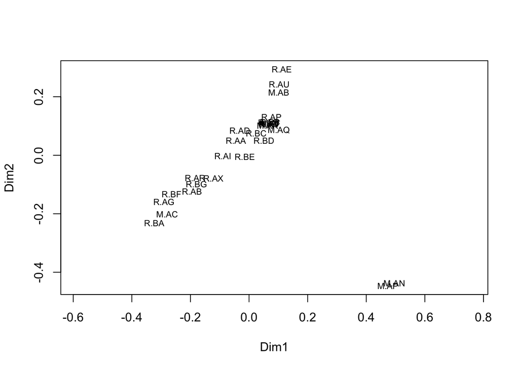

```r
fin71 <- here(path_data, 'virome_GVHD_patient.txt')
fin72 <- here(path_data, 'group_GVHD_patient.txt')
fin73 <- here(path_data, 'V.GVHD.PATIENT.txt')
fout71 <- path_target('GVHD-distance.csv')
fout72 <- path_target('pcoa.virome-G-patient.point.csv')
fout73 <- path_target('pcoa.otu.G.patient.species.csv')
fout74 <- path_target('V.GVHD.PATIENT.csv')
fout75 <- path_target("PCOA_GVHD_Patient_NEW1.png")

otu <- read.delim(fin71, row.names = 1, sep = '\t', stringsAsFactors = FALSE, check.names = FALSE) %>%
  t() %>%
  data.frame()

group <- read.delim(fin72, sep = '\t', stringsAsFactors = FALSE)
library(vegan)
distance <- vegdist(otu, method = 'bray')
pcoa <- cmdscale(distance, k = (nrow(otu) - 1), eig = TRUE)
write.csv(as.matrix(distance), fout71, quote = F)

ordiplot(scores(pcoa)[ ,c(1, 2)], type = 't')
```

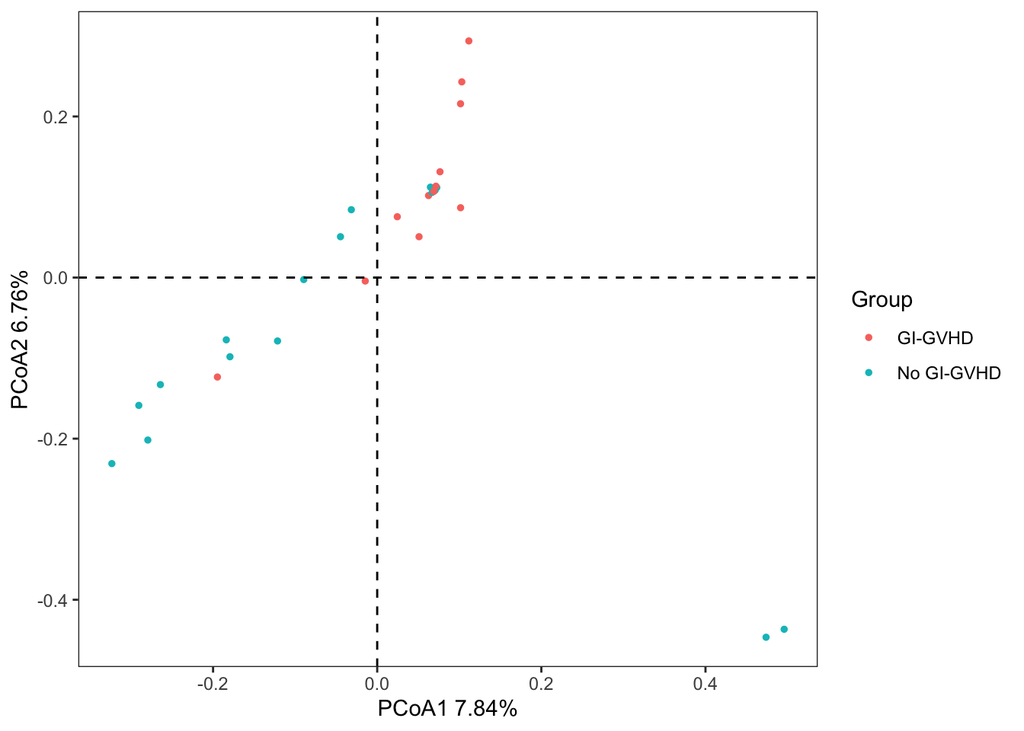

```r
point <- data.frame(pcoa$point)
write.csv(point, fout72)
species <- wascores(pcoa$points[,1:2], otu)
write.csv(species, fout73)
pcoa_eig <- (pcoa$eig)[1:2] / sum(pcoa$eig)
sample_group <- data.frame({pcoa$point})[1:2]
sample_group$names <- rownames(sample_group)
names(sample_group)[1:2] <- c('PCoA1', 'PCoA2')
sample_group <- merge(sample_group, group, by = 'names', all.x = TRUE)
write.csv(sample_group, fout74, quote = F)

#modify(sample_group)
pcoa <- read.delim(fin73, stringsAsFactors = F)
plot.theme = theme(plot.title=element_text(size=18, color="black", family  = "Arial", face= "plain",vjust=0.5,hjust=0.5),
                   axis.line=element_line(size=.5, colour="black"),
                   axis.ticks=element_line(color="black"),
                   axis.text= element_text(size=18, color="black", family  = "Arial", face= "plain", vjust=0.5, hjust=0.5),
                   axis.title = element_text(size=18, color="black", family  = "Arial",face= "plain", vjust=0.5, hjust=0.5),
                   legend.position="right",
                   legend.background=element_blank(),
                   legend.key=element_blank(),
                   legend.text = element_text(colour = 'black', size = 18,  family  = "Arial",face = 'plain'),
                   legend.title=element_blank(),
                   panel.background=element_blank(),
                   panel.grid.major=element_blank(),
                   panel.grid.minor=element_blank()  )

P0<-pcoa_plot <- ggplot(pcoa, aes(PCoA1, PCoA2, group = Group, color = Group))+
  geom_point(size=1)+
  theme_bw()+
  theme(panel.grid = element_blank())+
  geom_vline(xintercept = 0,lty="dashed")+
  geom_hline(yintercept = 0,lty="dashed")+
  labs(x=paste0("PCoA1 ",7.84,"%"),
       y=paste0("PCoA2 ",6.76,"%"))
P0
```

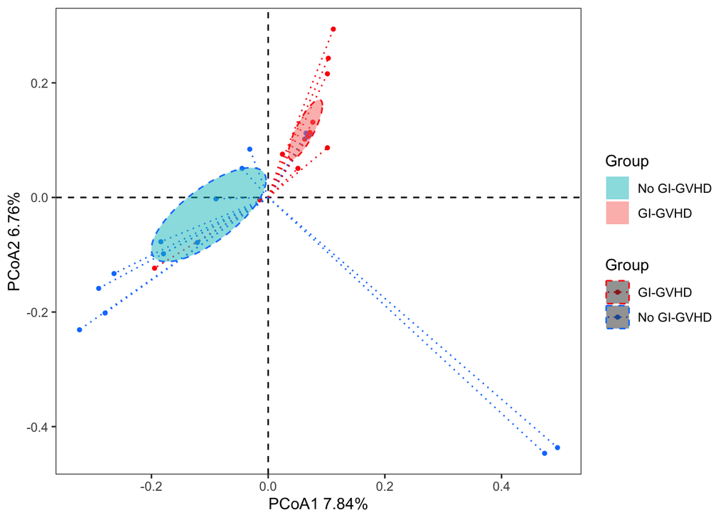

```r
P1<-P0+
  scale_color_manual(values =c("No GI-GVHD"="#0F7FFE","GI-GVHD"="#FB0106"))+
  geom_segment(data=NULL,aes(x=0,y=0,xend=PCoA1,yend=PCoA2),linetype = "dotted",arrow =NULL, size = 0.5) +
  scale_fill_discrete(breaks=c("No GI-GVHD","GI-GVHD"))+
  stat_ellipse(aes(colour = Group, fill=Group),linetype = 2, level=0.2, geom = "polygon", alpha=0.5)
P1
```

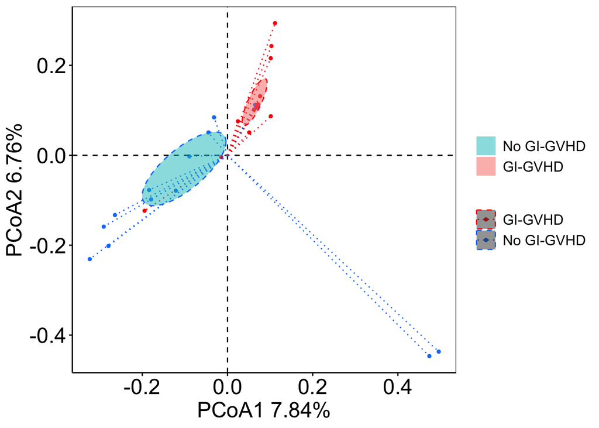

```r
plot.theme = theme(plot.title=element_text(size=18, color="black", family  = "Arial", face= "plain",vjust=0.5,hjust=0.5),
                   axis.line=element_line(size=.5, colour="black"),
                   axis.ticks=element_line(color="black"),
                   axis.text= element_text(size=18, color="black", family  = "Arial", face= "plain", vjust=0.5, hjust=0.5),
                   axis.title = element_text(size=18, color="black", family  = "Arial",face= "plain", vjust=0.5, hjust=0.5),
                   legend.position="right",
                   legend.background=element_blank(),
                   legend.key=element_blank(),
                   legend.text = element_text(colour = 'black', size = 12,  family  = "Arial",face = 'plain'),
                   legend.title=element_blank(),
                   panel.background=element_blank(),
                   panel.grid.major=element_blank(),
                   panel.grid.minor=element_blank()  )

p2 = P1 + plot.theme
p2
```

```r
ggsave(fout75, p2, width =1600,height = 1200,units = "px" )
```

### PCOA-AF.R

code from: `~/project/p0064gvhd/workflow/data/00-raw/result/Beta_Diversity/PCOA/PCOA-AF.R`

```
species scores not available
```

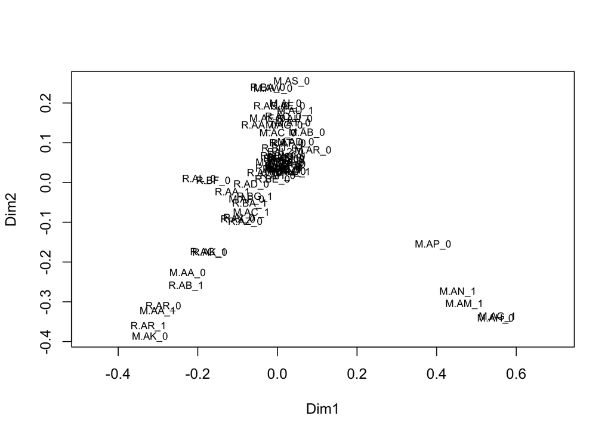

```r
fin61 <- here(path_data, 'virome_AF_patient.txt')
fin62 <- here(path_data, 'group_AF_patient_2.txt')
fin63 <- here(path_data, 'V.AF.patient.sample-group.txt')
fout61 <- path_target('AF-patient-distance.csv')
fout62 <- path_target('pcoa.virome-AF-patient.csv')
fout63 <- path_target('pcoa.otu.AF.patient.csv')
fout64 <- path_target('V.AF.patient.sample-group.csv')
fout65 <- path_target("PCOA_AF_patient_2.png")

otu <- read.delim(fin61, row.names = 1, sep = '\t', stringsAsFactors = FALSE, check.names = FALSE) %>%
  t() %>%
  data.frame()
group <- read.delim(fin62, sep = '\t', stringsAsFactors = FALSE)
distance <- vegdist(otu, method = 'bray')
pcoa <- cmdscale(distance, k = (nrow(otu) - 1), eig = TRUE)
write.csv(as.matrix(distance), fout61, quote = F)

ordiplot(scores(pcoa)[ ,c(1, 2)], type = 't')
```

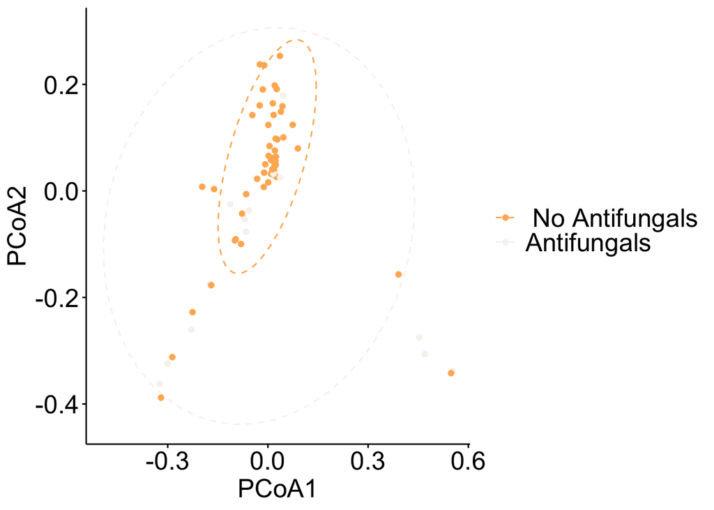

```r
point <- data.frame(pcoa$point)
write.csv(point, fout62)
species <- wascores(pcoa$points[,1:2], otu)
write.csv(species, fout63)
pcoa_eig <- (pcoa$eig)[1:2] / sum(pcoa$eig)
sample_group <- data.frame({pcoa$point})[1:2]
sample_group$names <- rownames(sample_group)
names(sample_group)[1:2] <- c('PCoA1', 'PCoA2')
sample_group <- merge(sample_group, group, by = 'names', all.x = TRUE)
write.csv(sample_group, fout64, quote = F)

#modify(sample_group)
pcoa <- read.delim(fin63, stringsAsFactors = F)

plot.theme = theme(plot.title=element_text(size=18, color="black", family  = "Arial", face= "plain",vjust=0.5,hjust=0.5),
                   axis.line=element_line(size=0.5, colour="black"),
                   axis.ticks=element_line(color="black"),
                   axis.text= element_text(size=18, color="black", family  = "Arial", face= "plain", vjust=0.5, hjust=0.5),
                   axis.title = element_text(size=18, color="black", family  = "Arial",face= "plain", vjust=0.5, hjust=0.5),
                   legend.position="right",
                   legend.background=element_blank(),
                   legend.key=element_blank(),
                   legend.text = element_text(colour = 'black', size = 18,  family  = "Arial",face = 'plain'),
                   legend.title=element_blank(),
                   panel.background=element_blank(),
                   panel.grid.major=element_blank(),
                   panel.grid.minor=element_blank()  )
#stat_ellipse(level = 0.95, show.legend = F)(??Բ????????)
pcoa_plot <- ggplot(pcoa, aes(PCoA1, PCoA2, group = group, color = group))+
  stat_ellipse(aes(colour = group),level=0.95,linetype = 2)+
  geom_point()+scale_color_manual(values =c(" No Antifungals"="#FFB562","Antifungals"="#F9F2ED"))+
  scale_fill_discrete(breaks=c("NO","YES"))

p1 = pcoa_plot + plot.theme
p1
```

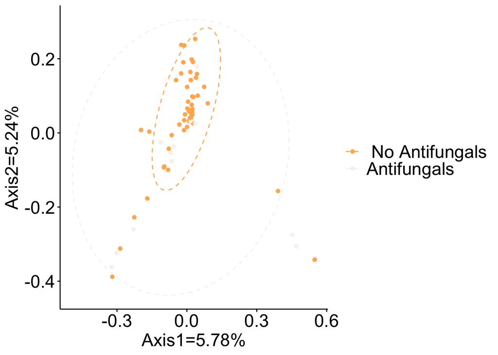

```r
p2 = p1 + xlab(paste("Axis1=",5.78,"%",sep=""))+ylab(paste("Axis2=",5.24,"%",sep=""))
p2
```

```r
ggsave(fout65, p2, width =2400,height = 1200,units = "px" )
```

### PERMANOVA_TEST.R

code from: `~/project/p0064gvhd/workflow/data/00-raw/result/Beta_Diversity/PCOA/PERMANOVA_TEST.R`

```r
fin51 <- here(path_data, 'virome-RA-Time.txt')
fin52 <- here(path_data, 'grouping-Time.txt')
fout51 <- path_target('PERMANOVA.result_Time.txt')
fout52 <- path_target('PERMANOVA.result_Time_points.txt')

otu <- read.delim(fin51, row.names = 1, sep = '\t', stringsAsFactors = FALSE, check.names = FALSE) %>%
  t() %>%
  data.frame()

group <- read.delim(fin52, sep = '\t', stringsAsFactors = FALSE)
adonis_result <- adonis(otu~group, group, distance = 'bray', permutations = 999)
otuput <- data.frame(adonis_result$aov.tab, check.names = FALSE, stringsAsFactors = FALSE)
otuput <- cbind(rownames(otuput), otuput)
names(otuput) <- c('', 'Df', 'Sums of squares', 'Mean squares', 'F.Model', 'Variation (R2)', 'Pr (>F)')
write.table(otuput, file = fout51, row.names = FALSE, sep = '\t', quote = FALSE, na = '')


##PERMANOVA 分析（使用循环处理，进行小分组间比较，如两组间）
#推荐使用 OTU 丰度表作为输入数据，每次筛选分组后重新计算样本距离，避免由于样本数减少可能导致的距离变动而造成误差
group_name <- unique(group$group)

adonis_result_two <- NULL
for (i in 1:(length(group_name) - 1)) {
  for (j in (i + 1):length(group_name)) {
    group_ij <- subset(group, group %in% c(group_name[i], group_name[j]))
    otu_ij <- otu[group_ij$names, ]
    adonis_result_otu_ij <- adonis(otu_ij~group, group_ij, permutations = 999, distance = 'bray')     #Bray-Curtis 距离测度，基于 999 次置换
    adonis_result_two <- rbind(adonis_result_two, c(paste(group_name[i], group_name[j], sep = '/'), 'Bray-Curtis', unlist(data.frame(adonis_result_otu_ij$aov.tab, check.names = FALSE)[1, ])))
  }
}
adonis_result_two <- data.frame(adonis_result_two, stringsAsFactors = FALSE)
names(adonis_result_two) <- c('group', 'distance', 'Df', 'Sums of squares', 'Mean squares', 'F.Model', 'Variation (R2)', 'Pr (>F)')

#可选添加 p 值校正，例如 Benjamini 校正
write.table(adonis_result_two, fout52, row.names = FALSE, sep = '\t', quote = FALSE, na = '')
```

### PERMANOVA-GVHD.R

code from: `~/project/p0064gvhd/workflow/data/00-raw/result/Beta_Diversity/PCOA/PERMANOVA-GVHD.R`

```r
fin41 <- here(path_data, 'virome_GVHD_patient.txt')
fin42 <- here(path_data, 'group_GVHD_patient.txt')
fout41 <- path_target('PERMANOVA.result_GVHD_Patient.txt')
otu <- read.delim(fin41, row.names = 1, sep = '\t', stringsAsFactors = FALSE, check.names = FALSE)
otu <- data.frame(t(otu))
group <- read.delim(fin42, sep = '\t', stringsAsFactors = FALSE)
##PERMANOVA 分析（使用循环处理，进行小分组间比较，如两组间）
#推荐使用 OTU 丰度表作为输入数据，每次筛选分组后重新计算样本距离，避免由于样本数减少可能导致的距离变动而造成误差
group_name <- unique(group$group)

adonis_result_two <- NULL
for (i in 1:(length(group_name) - 1)) {
  for (j in (i + 1):length(group_name)) {
    group_ij <- subset(group, group %in% c(group_name[i], group_name[j]))
    otu_ij <- otu[group_ij$names, ]
    adonis_result_otu_ij <- adonis(otu_ij~group, group_ij, permutations = 999, distance = 'bray')     #Bray-Curtis 距离测度，基于 999 次置换
    adonis_result_two <- rbind(adonis_result_two, c(paste(group_name[i], group_name[j], sep = '/'), 'Bray-Curtis', unlist(data.frame(adonis_result_otu_ij$aov.tab, check.names = FALSE)[1, ])))
  }
}
```

```
'adonis' will be deprecated: use 'adonis2' instead
```

```r
adonis_result_two <- data.frame(adonis_result_two, stringsAsFactors = FALSE)
names(adonis_result_two) <- c('group', 'distance', 'Df', 'Sums of squares', 'Mean squares', 'F.Model', 'Variation (R2)', 'Pr (>F)')

#可选添加 p 值校正，例如 Benjamini 校正
write.table(adonis_result_two, fout41, row.names = FALSE, sep = '\t', quote = FALSE, na = '')
```

### PERMANOVA-ABX.R

code from: `~/project/p0064gvhd/workflow/data/00-raw/result/Beta_Diversity/PCOA/PERMANOVA-ABX.R`

```r
fin31 <- here(path_data, 'virome_ABX_patient.txt')
fin32 <- here(path_data, 'group_ABX_patient.txt')
fout31 <- path_target('PERMANOVA.result_ABX_Patient.txt')

otu <- read.delim(fin31, row.names = 1, sep = '\t', stringsAsFactors = FALSE, check.names = FALSE) %>%
  t() %>%
  data.frame()

group <- read.delim(fin32, sep = '\t', stringsAsFactors = FALSE)
##PERMANOVA 分析（使用循环处理，进行小分组间比较，如两组间）
#推荐使用 OTU 丰度表作为输入数据，每次筛选分组后重新计算样本距离，避免由于样本数减少可能导致的距离变动而造成误差
group_name <- unique(group$group)

adonis_result_two <- NULL
for (i in 1:(length(group_name) - 1)) {
  for (j in (i + 1):length(group_name)) {
    group_ij <- subset(group, group %in% c(group_name[i], group_name[j]))
    otu_ij <- otu[group_ij$names, ]
    adonis_result_otu_ij <- adonis(otu_ij~group, group_ij, permutations = 999, distance = 'bray')     #Bray-Curtis 距离测度，基于 999 次置换
    adonis_result_two <- rbind(adonis_result_two, c(paste(group_name[i], group_name[j], sep = '/'), 'Bray-Curtis', unlist(data.frame(adonis_result_otu_ij$aov.tab, check.names = FALSE)[1, ])))
  }
}
```

```
'adonis' will be deprecated: use 'adonis2' instead
```

```r
adonis_result_two <- data.frame(adonis_result_two, stringsAsFactors = FALSE)
names(adonis_result_two) <- c('group', 'distance', 'Df', 'Sums of squares', 'Mean squares', 'F.Model', 'Variation (R2)', 'Pr (>F)')

#可选添加 p 值校正，例如 Benjamini 校正
write.table(adonis_result_two, fout31, row.names = FALSE, sep = '\t', quote = FALSE, na = '')
```

### PCOA-MIX.R

code from: `~/project/p0064gvhd/workflow/data/00-raw/result/Beta_Diversity/PCOA/PCOA-MIX.R`

```
species scores not available
```

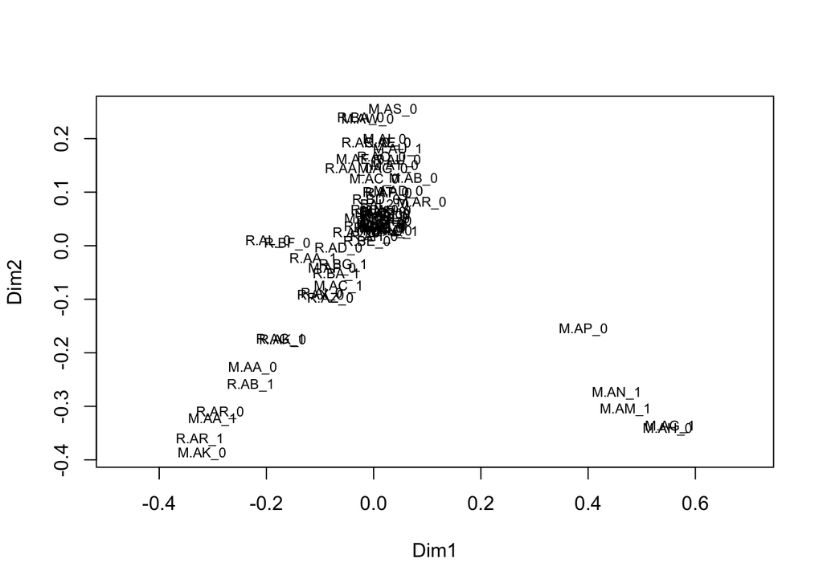

```r
fin21 <- here(path_data, 'virome_AF_patient.txt')
fin22 <- here(path_data, 'group_AF_patient.txt')
fout20 <- path_target('AF-patient-distance.csv')
fout21 <- path_target('pcoa.AF_PATIENT.csv')
fout22 <- path_target('pcoa.AF_PATIENT_SPECIES.csv')
fout23 <- path_target('V.AF_PATIENT.csv')
fout24 <- path_target("PCOA_AF_patient_NEW_1.png")

otu <- read.delim(fin21, row.names = 1, sep = '\t', stringsAsFactors = FALSE, check.names = FALSE) %>%
  t() %>%
  data.frame()

group <- read.delim(fin22, sep = '\t', stringsAsFactors = FALSE)

distance <- vegdist(otu, method = 'bray')
pcoa <- cmdscale(distance, k = (nrow(otu) - 1), eig = TRUE)
write.csv(as.matrix(distance), fout20, quote = F)

ordiplot(scores(pcoa)[ ,c(1, 2)], type = 't')
```

```r
summary(pcoa)
```

```
       Length Class  Mode
points 4692   -none- numeric
eig      69   -none- numeric
x         0   -none- NULL
ac        1   -none- numeric
GOF       2   -none- numeric
```

```r
pcoa$eig
```

```
 [1]  1.890813e+00  1.715454e+00  1.285441e+00  1.183916e+00  1.036350e+00
 [6]  9.687139e-01  9.143261e-01  8.199455e-01  7.753012e-01  7.621537e-01
[11]  7.080565e-01  6.810422e-01  6.470431e-01  6.086077e-01  5.884791e-01
[16]  5.485969e-01  5.446269e-01  5.297217e-01  5.228783e-01  5.181457e-01
[21]  5.091430e-01  5.030080e-01  5.022200e-01  5.007796e-01  5.002913e-01
[26]  4.966219e-01  4.940145e-01  4.913146e-01  4.887280e-01  4.856297e-01
[31]  4.809879e-01  4.737758e-01  4.700942e-01  4.666384e-01  4.611148e-01
[36]  4.546293e-01  4.473256e-01  4.420721e-01  4.395880e-01  4.326318e-01
[41]  4.095838e-01  4.059842e-01  3.962267e-01  3.768147e-01  3.412266e-01
[46]  3.124991e-01  3.098859e-01  2.899186e-01  2.822597e-01  2.711274e-01
[51]  2.497084e-01  2.451113e-01  2.208145e-01  2.109532e-01  2.079174e-01
[56]  2.011161e-01  1.850037e-01  1.786523e-01  1.572155e-01  1.429524e-01
[61]  1.395826e-01  1.128705e-01  9.385298e-02  8.346114e-02  6.089521e-02
[66]  3.780953e-02  2.033079e-02  4.120517e-04 -4.658298e-16
```

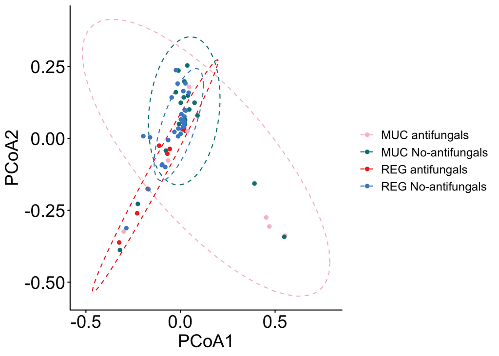

```r
point <- data.frame(pcoa$point)
write.csv(point, fout21)
species <- wascores(pcoa$points[,1:2], otu)
write.csv(species, fout22)
pcoa_eig <- (pcoa$eig)[1:2] / sum(pcoa$eig)
sample_group <- data.frame({pcoa$point})[1:2]
sample_group$names <- rownames(sample_group)
names(sample_group)[1:2] <- c('PCoA1', 'PCoA2')
sample_group <- merge(sample_group, group, by = 'names', all.x = TRUE)
write.csv(sample_group, fout23, quote = F, row.names = F)

#modify(sample_group)
library(ggplot2)
pcoa <- data.table::fread(fout23)
#?趨????
plot.theme = theme(plot.title=element_text(size=18, color="black", family  = "Arial", face= "plain",vjust=0.5,hjust=0.5),
                   axis.line=element_line(size=0.5, colour="black"),
                   axis.ticks=element_line(color="black"),
                   axis.text= element_text(size=18, color="black", family  = "Arial", face= "plain", vjust=0.5, hjust=0.5),
                   axis.title = element_text(size=18, color="black", family  = "Arial",face= "plain", vjust=0.5, hjust=0.5),
                   legend.position="right",
                   legend.background=element_blank(),
                   legend.key=element_blank(),
                   legend.text = element_text(colour = 'black', size = 12,  family  = "Arial",face = 'plain'),
                   legend.title=element_blank(),
                   panel.background=element_blank(),
                   panel.grid.major=element_blank(),
                   panel.grid.minor=element_blank()  )
#stat_ellipse(level = 0.95, show.legend = F)(??Բ????????)
pcoa_plot <- ggplot(pcoa, aes(PCoA1, PCoA2, group = group, color = group))+
  stat_ellipse(aes(colour = group),level=0.95,linetype = 2)+
  geom_point()+scale_color_manual(values =c("MUC No-antifungals"="#008082","REG No-antifungals"="#498bca","MUC antifungals"="#f9bfcb","REG antifungals"="#ee3224"))+
  scale_fill_discrete(breaks=c("MUC No-antifungals","REG No-antifungals","MUC antifungals","REG antifungals"))

p1 = pcoa_plot + plot.theme
p1
```

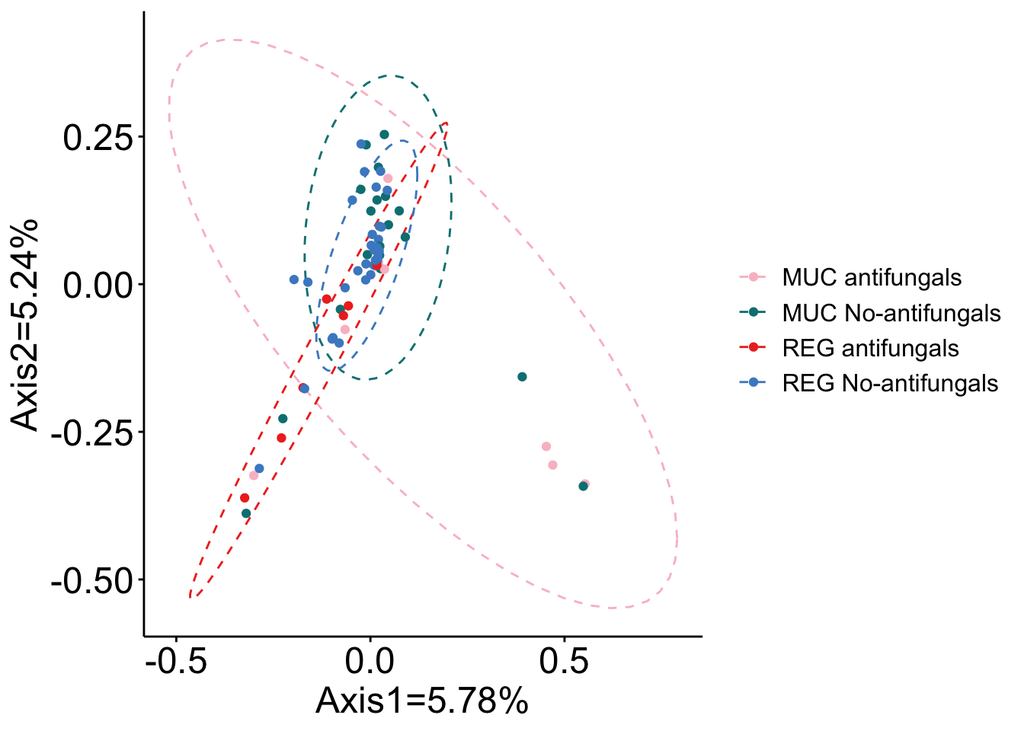

```r
p2 = p1 + xlab(paste("Axis1=",5.78,"%",sep=""))+ylab(paste("Axis2=",5.24,"%",sep=""))
p2
```

```r
ggsave(fout24, p2, width =2400,height = 1200,units = "px" )
```

### PERMANOVA-AF.R

code from: `~/project/p0064gvhd/workflow/data/00-raw/result/Beta_Diversity/PCOA/PERMANOVA-AF.R`

```r
fin11 <- here(path_data, 'virome_AF_patient.txt')
fin12 <- here(path_data, 'group_AF_patient.txt')
fout11 <- path_target('PERMANOVA.result_AF_PATIENT.txt')

otu <- read.delim(fin11, row.names = 1, sep = '\t', stringsAsFactors = FALSE, check.names = FALSE) %>%
  t() %>%
  data.frame()

group <- read.delim(fin12, sep = '\t', stringsAsFactors = FALSE)
##PERMANOVA 分析（使用循环处理，进行小分组间比较，如两组间）
#推荐使用 OTU 丰度表作为输入数据，每次筛选分组后重新计算样本距离，避免由于样本数减少可能导致的距离变动而造成误差
group_name <- unique(group$group)

adonis_result_two <- NULL
for (i in 1:(length(group_name) - 1)) {
  for (j in (i + 1):length(group_name)) {
    group_ij <- subset(group, group %in% c(group_name[i], group_name[j]))
    otu_ij <- otu[group_ij$names, ]
    adonis_result_otu_ij <- adonis(otu_ij~group, group_ij, permutations = 999, distance = 'bray')     #Bray-Curtis 距离测度，基于 999 次置换
    adonis_result_two <- rbind(adonis_result_two, c(paste(group_name[i], group_name[j], sep = '/'), 'Bray-Curtis', unlist(data.frame(adonis_result_otu_ij$aov.tab, check.names = FALSE)[1, ])))
  }
}
```

```
'adonis' will be deprecated: use 'adonis2' instead
'adonis' will be deprecated: use 'adonis2' instead
'adonis' will be deprecated: use 'adonis2' instead
'adonis' will be deprecated: use 'adonis2' instead
'adonis' will be deprecated: use 'adonis2' instead
'adonis' will be deprecated: use 'adonis2' instead
```

```r
adonis_result_two <- data.frame(adonis_result_two, stringsAsFactors = FALSE)
names(adonis_result_two) <- c('group', 'distance', 'Df', 'Sums of squares', 'Mean squares', 'F.Model', 'Variation (R2)', 'Pr (>F)')

#可选添加 p 值校正，例如 Benjamini 校正
write.table(adonis_result_two, fout11, row.names = FALSE, sep = '\t', quote = FALSE, na = '')
```

## Files written

These files have been written to the target directory, `data/32-beta_diversity`:

```r
projthis::proj_dir_info(path_target())
```

```
# A tibble: 28 × 4
   path                       type         size modification_time
   <fs::path>                 <fct> <fs::bytes> <dttm>
 1 ABX_patient_distance.csv   file       126.1K 2023-03-04 22:53:21
 2 AF-patient-distance.csv    file          83K 2023-03-04 22:53:53
 3 GVHD-distance.csv          file        13.5K 2023-03-04 22:53:23
 4 GVHD_patient_distance.csv  file        13.5K 2023-03-04 22:53:22
 5 PCOA_ABX_patient_NEW.png   file       117.3K 2023-03-04 22:53:22
 6 PCOA_AF_patient_2.png      file         117K 2023-03-04 22:53:28
 7 PCOA_AF_patient_NEW_1.png  file       166.7K 2023-03-04 22:53:54
 8 PCOA_GVHD_Patient_NEW1.png file       107.5K 2023-03-04 22:53:25
 9 PCOA_GVHD_patient_NEW.png  file        95.2K 2023-03-04 22:53:23
10 PCOA_TIME_TRY123_NEW.png   file       128.8K 2023-03-04 22:53:20
# … with 18 more rows
```